# Frequency analysis

anonymous

16/06/2021

## Setup

Load packages:

```r
library(tidyverse) # for data processing
library(brms) # for bayesian models
library(effsize) # for cohen's d
library(patchwork) # for double plots
library(tidybayes) # for half-eye plots
```

Load data:

```r
# Frequencies:

COCA <- read_csv('../data/add_subtract_all_frequencies.csv')
```

Quick glance at the structure of the frequency table. Each row is a word, then there’s all the frequency information from the different sub-corpora.

```r
COCA
```

```
## # A tibble: 1,610 × 6
##    word        pair                 type      freq file            register
##    <chr>       <chr>                <chr>    <dbl> <chr>           <chr>
##  1 add         add/subtract         add       3234 w_acad_1990.txt academic
##  2 subtract    add/subtract         subtract    30 w_acad_1990.txt academic
##  3 addition    addition/subtraction add       1441 w_acad_1990.txt academic
##  4 subtraction addition/subtraction subtract     3 w_acad_1990.txt academic
##  5 plus        plus/minus           add        280 w_acad_1990.txt academic
##  6 minus       plus/minus           subtract    28 w_acad_1990.txt academic
##  7 more        more/less            add       9862 w_acad_1990.txt academic
##  8 less        more/less            subtract  4653 w_acad_1990.txt academic
##  9 most        most/least           add       6210 w_acad_1990.txt academic
## 10 least       most/least           subtract  1453 w_acad_1990.txt academic
## # … with 1,600 more rows
```

## Descriptive stats

Get the sum per word:

```r
COCA_freqs <- COCA %>%
  group_by(pair, type, word) %>%
  summarize(freq = sum(freq))
COCA_freqs
```

```
## # A tibble: 14 × 4
## # Groups:   pair, type [14]
##    pair                 type     word           freq
##    <chr>                <chr>    <chr>         <dbl>
##  1 add/subtract         add      add          361246
##  2 add/subtract         subtract subtract       1802
##  3 addition/subtraction add      addition      78032
##  4 addition/subtraction subtract subtraction     313
##  5 increase/decrease    add      increase     110178
##  6 increase/decrease    subtract decrease      14078
##  7 many/few             add      many         388983
##  8 many/few             subtract few          230946
##  9 more/less            add      more        1051783
## 10 more/less            subtract less         435504
## 11 most/least           add      most         596854
## 12 most/least           subtract least        139502
## 13 plus/minus           add      plus          35247
## 14 plus/minus           subtract minus          4791
```

Calculate by what factor the add-type word is more frequent than the subtract-type word:

```r
add_totals <- COCA_freqs[rep(c(TRUE, FALSE), 7), ]$freq
subtract_totals <- COCA_freqs[rep(c(FALSE, TRUE), 7), ]$freq

ratios <- add_totals / subtract_totals
ratios <- tibble(pair = COCA_freqs[rep(c(TRUE, FALSE), 7), ]$pair,
       ratio = ratios)

ratios
```

```
## # A tibble: 7 × 2
##   pair                  ratio
##   <chr>                 <dbl>
## 1 add/subtract         200.
## 2 addition/subtraction 249.
## 3 increase/decrease      7.83
## 4 many/few               1.68
## 5 more/less              2.42
## 6 most/least             4.28
## 7 plus/minus             7.36
```

Check how much overall more frequent the add-type word is:

```r
COCA_total <- COCA_freqs %>%
  group_by(type) %>%
  summarize(total = sum(freq))

COCA_total
```

```
## # A tibble: 2 × 2
##   type       total
##   <chr>      <dbl>
## 1 add      2622323
## 2 subtract  826936
```

Compute Cohen’s d based on the log-transformed data:

```r
COCA_freqs <- mutate(COCA_freqs,
                     logfreq = log10(freq))

add_logs <- filter(COCA_freqs, type == 'add')$logfreq
subtract_logs <- filter(COCA_freqs, type == 'subtract')$logfreq

cohen.d(add_logs, subtract_logs, paired = TRUE)
```

```
##
## Cohen's d
##
## d estimate: 0.9436149 (large)
## 95 percent confidence interval:
##     lower     upper
## 0.1903038 1.6969261
```

Get the raw materials for annotations ready:

```r
annotate_freqs <- filter(COCA_freqs, type == 'subtract') %>% pull(logfreq)
labels <- filter(COCA_freqs, type == 'subtract') %>% pull(pair)
```

Make a plot of this:

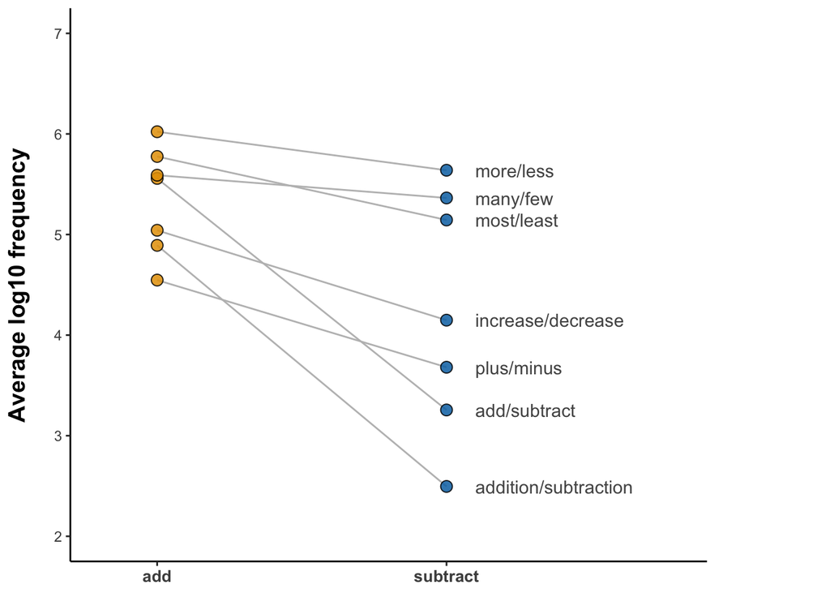

```r
# Define plot and aesthetics:

freq_p <- COCA_freqs %>%
  ggplot(aes(x = type, y = logfreq, fill = type, group = pair))

# Add geoms:

freq_p <- freq_p +
  geom_line(col = 'grey') +
  geom_point(size = 3, shape = 21, alpha = 0.85) +
  annotate(geom = 'text',
           x = rep(2.1, nrow(COCA_freqs) / 2),
           y = annotate_freqs,
           label = labels,
           hjust = 0,
           col = 'grey33')

# Add scales and axes labels:

freq_p <- freq_p +
  scale_y_continuous(breaks = seq(2, 7, 1)) +
  scale_fill_manual(values = c("#E69F00", "#0072B2")) +
  coord_cartesian(xlim = c(1.3, 2.3), ylim = c(2, 7),
                  clip = 'off') +
  xlab(NULL) +
  ylab('Average log10 frequency')

# Add themes:

freq_p <- freq_p +
  theme_classic() +
  theme(legend.position = 'none') +
  theme(axis.title.y = element_text(margin = margin(t = 0, r = 15,
                                                    b = 0, l = 0),
                                    size = 14, face = 'bold'),
        axis.text.x = element_text(face = 'bold', size = 10),
        plot.margin = margin(r = 75, l = 5, b = 5, t = 5))

# Show and save:

freq_p
```

```r
ggsave(plot = freq_p,
       filename = '../figures/pdf/word_frequencies.pdf',
       width = 4, height = 4)

ggsave(plot = freq_p,
       filename = '../figures/png/word_frequencies.png',
       width = 4, height = 4)

ggsave(plot = freq_p,
       filename = '../figures/tiff/word_frequencies.tiff',
       width = 4, height = 4)
```

## Bayesian model

Make subtract the reference level of the `type` column. I’d wager it’s easier to think about stuff moving towards addition, which also gives us positive rather than negative coefficients.

```r
COCA <- mutate(COCA,
               type = factor(type, levels = c('subtract', 'add')))
```

Let’s find an appropriate weakly informative prior. We need to keep in mind that the model is in log space, and we need to keep the intercept in mind. We’ll use `type` as treatment coded predictor, so `subtract` will be the reference level:

```r
intercept <- log(mean(filter(COCA, type == 'subtract')$freq))

intercept
```

```
## [1] 6.93464
```

What would a normal distribution (centered at zero) with SD = 1 amount to assuming as likely changes? 68% of the prior probability mass for the differences would be:

```r
diff(c(exp(intercept + 1), exp(intercept - 1)))
```

```
## [1] -2414.45
```

That’s a difference in around 2,400. What about SD = 2? 68% of the prior probability mass for the differences would be:

```r
diff(c(exp(intercept + 2), exp(intercept - 2)))
```

```
## [1] -7451.382
```

```r
my_prior <- prior(normal(0, 2), class = 'b')
```

Model this with a negative binomial regression model:

```r
freq_mdl <- brm(freq ~ 1 + type +
                  (1 + type|pair) + (1 + type|file) + (1 + type|register),
               data = COCA,

               family = negbinomial,
               prior = my_prior,

               # MCMC settings:

               seed = 42, chains = 4, cores = 4,
               warmup = 2000, iter = 4000,
               control = list(adapt_delta = 0.99,
                              max_treedepth = 13))
```

Save the model:

```r
save(freq_mdl, file = '../models/frequency_model.RData')
```

Check the model:

```r
freq_mdl
```

```
##  Family: negbinomial
##   Links: mu = log; shape = identity
## Formula: freq ~ 1 + type + (1 + type | pair) + (1 + type | file) + (1 + type | register)
##    Data: COCA (Number of observations: 1610)
##   Draws: 4 chains, each with iter = 4000; warmup = 2000; thin = 1;
##          total post-warmup draws = 8000
##
## Group-Level Effects:
## ~file (Number of levels: 115)
##                        Estimate Est.Error l-95% CI u-95% CI Rhat Bulk_ESS
## sd(Intercept)              0.07      0.03     0.01     0.12 1.00     1565
## sd(typeadd)                0.02      0.02     0.00     0.06 1.00     5100
## cor(Intercept,typeadd)    -0.20      0.57    -0.97     0.91 1.00     9800
##                        Tail_ESS
## sd(Intercept)              1594
## sd(typeadd)                3775
## cor(Intercept,typeadd)     5822
##
## ~pair (Number of levels: 7)
##                        Estimate Est.Error l-95% CI u-95% CI Rhat Bulk_ESS
## sd(Intercept)              2.86      0.79     1.78     4.79 1.00     2928
## sd(typeadd)                2.15      0.61     1.31     3.71 1.00     3321
## cor(Intercept,typeadd)    -0.74      0.20    -0.96    -0.22 1.00     3886
##                        Tail_ESS
## sd(Intercept)              4383
## sd(typeadd)                4329
## cor(Intercept,typeadd)     4401
##
## ~register (Number of levels: 5)
##                        Estimate Est.Error l-95% CI u-95% CI Rhat Bulk_ESS
## sd(Intercept)              0.73      0.44     0.30     1.86 1.00     2837
## sd(typeadd)                0.48      0.31     0.19     1.32 1.00     3893
## cor(Intercept,typeadd)    -0.04      0.44    -0.81     0.77 1.00     4805
##                        Tail_ESS
## sd(Intercept)              4987
## sd(typeadd)                4932
## cor(Intercept,typeadd)     5052
##
## Population-Level Effects:
##           Estimate Est.Error l-95% CI u-95% CI Rhat Bulk_ESS Tail_ESS
## Intercept     5.40      1.05     3.35     7.53 1.00     2068     3069
## typeadd       2.10      0.79     0.45     3.62 1.00     2430     3724
##
## Family Specific Parameters:
##       Estimate Est.Error l-95% CI u-95% CI Rhat Bulk_ESS Tail_ESS
## shape     5.13      0.21     4.74     5.55 1.00     9282     5216
##
## Draws were sampled using sampling(NUTS). For each parameter, Bulk_ESS
## and Tail_ESS are effective sample size measures, and Rhat is the potential
## scale reduction factor on split chains (at convergence, Rhat = 1).
```

```r
hypothesis(freq_mdl, 'typeadd < 0')
```

```
## Hypothesis Tests for class b:
##      Hypothesis Estimate Est.Error CI.Lower CI.Upper Evid.Ratio Post.Prob Star
## 1 (typeadd) < 0      2.1      0.79     0.79     3.37       0.01      0.01
## ---
## 'CI': 90%-CI for one-sided and 95%-CI for two-sided hypotheses.
## '*': For one-sided hypotheses, the posterior probability exceeds 95%;
## for two-sided hypotheses, the value tested against lies outside the 95%-CI.
## Posterior probabilities of point hypotheses assume equal prior probabilities.
```

Or the reverse, depending on how things are ought to be reported:

```r
hypothesis(freq_mdl, 'typeadd > 0')
```

```
## Hypothesis Tests for class b:
##      Hypothesis Estimate Est.Error CI.Lower CI.Upper Evid.Ratio Post.Prob Star
## 1 (typeadd) > 0      2.1      0.79     0.79     3.37     136.93      0.99    *
## ---
## 'CI': 90%-CI for one-sided and 95%-CI for two-sided hypotheses.
## '*': For one-sided hypotheses, the posterior probability exceeds 95%;
## for two-sided hypotheses, the value tested against lies outside the 95%-CI.
## Posterior probabilities of point hypotheses assume equal prior probabilities.
```

Visualize the posterior distribution of the `type` effect:

```r
freq_samples <- posterior_samples(freq_mdl)
```

Plot this:

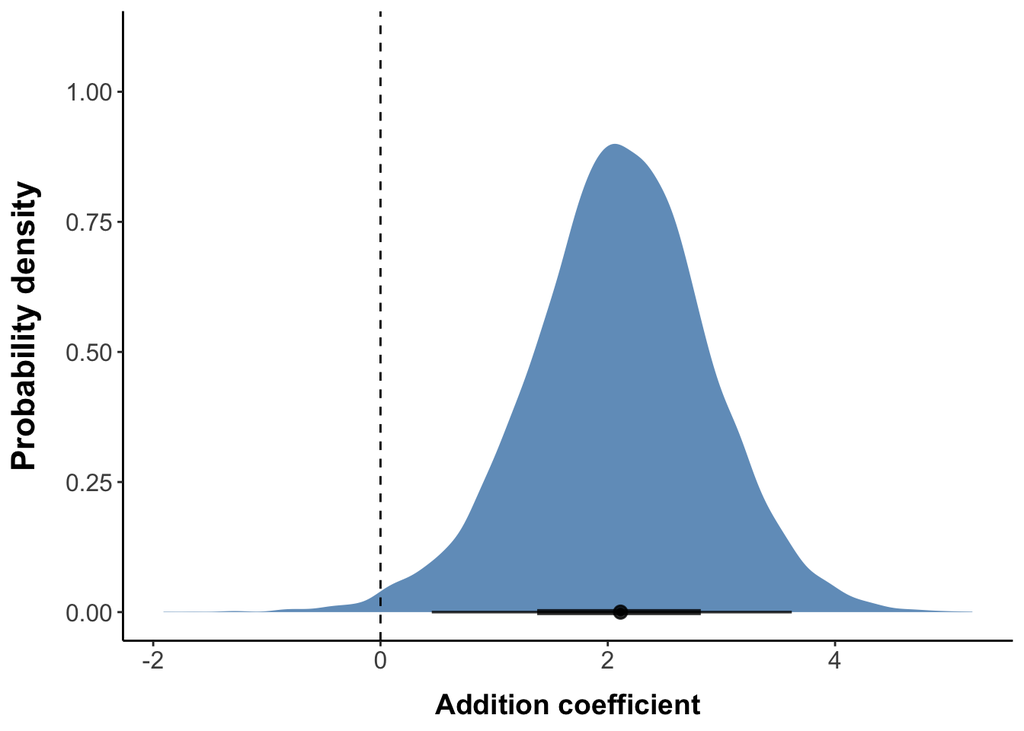

```r
post_p <- freq_samples %>%
  ggplot(aes(x = b_typeadd)) +
  stat_halfeye(fill = 'steelblue', alpha = 0.8) +
  geom_vline(xintercept = 0, linetype = 'dashed')

post_p <- post_p +
  xlab('Addition coefficient') +
  ylab('Probability density') +
  coord_cartesian(y = c(0, 1.1)) +
  scale_y_continuous(breaks = seq(0, 1, 0.25))

post_p <- post_p +
  theme_classic() +
  theme(axis.text.x = element_text(size = 12),
        axis.text.y = element_text(size = 12),
        axis.title.x = element_text(face = 'bold', size = 14,
                                    margin = margin(t = 10)),
        axis.title.y = element_text(face = 'bold', size = 16,
                                    margin = margin(r = 12)))

# Show and save:

post_p
```

```r
ggsave(plot = post_p, filename = '../figures/pdf/frequency_posterior.pdf',
       width = 7, height = 5)

ggsave(plot = post_p, filename = '../figures/png/frequency_posterior.png',
       width = 7, height = 5)

ggsave(plot = post_p, filename = '../figures/tiff/frequency_posterior.tiff',
       width = 7, height = 5)
```

## Put both into a double plot

Put the raw frequencies and the posterior into a double plot:

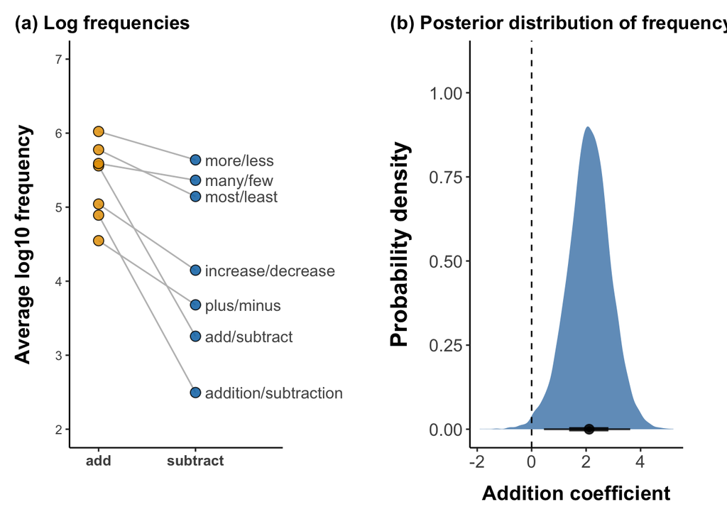

```r
freq_p <- freq_p +
  ggtitle('(a) Log frequencies') +
  theme(plot.title = element_text(face = 'bold'),
        plot.title.position = 'plot')

post_p <- post_p +
  ggtitle('(b) Posterior distribution of frequency difference') +
  theme(plot.title = element_text(face = 'bold'),
        plot.margin = margin(r = 25),
        plot.title.position = 'plot')

# Combine:

both_p <- freq_p + post_p

# Show and save:

both_p
```

```r
ggsave(filename = '../figures/pdf/frequencies_double_plot.pdf',
       width = 10, height = 4.5)

ggsave(filename = '../figures/png/frequencies_double_plot.png',
       width = 10, height = 4.5)

ggsave(filename = '../figures/tiff/frequencies_double_plot.tiff',
       width = 10, height = 4.5)
```

## Posterior predictive checks

First, the regular `pp_check()` function, continuous:

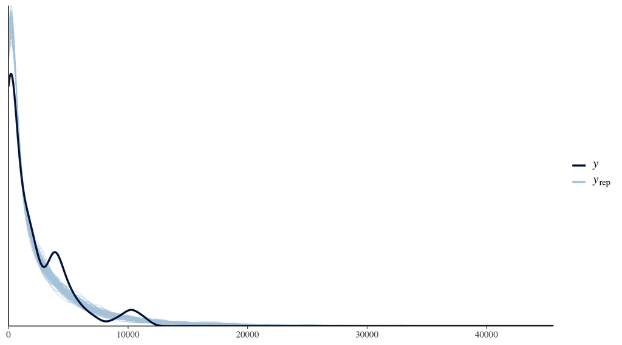

```r
pp_check(freq_mdl, nsample = 100)
```

Then ECDF:

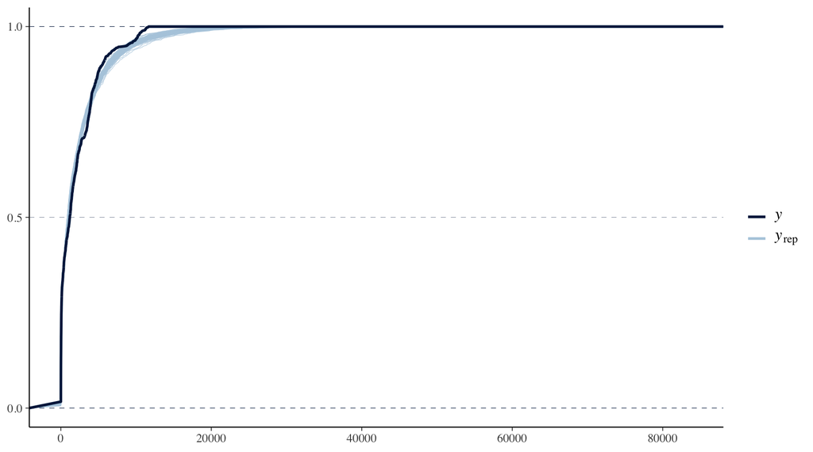

```r
pp_check(freq_mdl, nsample = 100, type = 'ecdf_overlay')
```

Not quite.

## Sensitivity analysis to assess impact of different prior choices

Assess how different priors impact the analysis, focusing on the standard deviation of the weakly informative prior:

```r
stronger_prior <- prior(normal(0, 1), class = 'b')
even_stronger_prior <- prior(normal(0, 0.5), class = 'b')
extreme_prior <- prior(normal(0, 0.1), class = 'b')
```

Build different models:

```r
# Stronger priors, SD = 1:

mdl_stronger <- brm(freq ~ 1 + type +
                      (1 + type|pair) +
                      (1 + type|file) +
                      (1 + type|register),
                    data = COCA,

                    family = negbinomial,
                    prior = stronger_prior,

                    # MCMC settings:

                    seed = 42, chains = 4, cores = 4,
                    warmup = 2000, iter = 4000,
                    control = list(adapt_delta = 0.99,
                                   max_treedepth = 13))
# Even stronger priors, SD = 0.5:

mdl_more_stronger <- brm(freq ~ 1 + type +
                           (1 + type|pair) + (1 + type|file) +
                           (1 + type|register),
                         data = COCA,

                         family = negbinomial,
                         prior = even_stronger_prior,

                         # MCMC settings:

                         seed = 42, chains = 4, cores = 4,
                         warmup = 2000, iter = 4000,
                         control = list(adapt_delta = 0.99,
                                        max_treedepth = 13))
# Even stronger priors, SD = 0.1:

mdl_extreme <- brm(freq ~ 1 + type +
                     (1 + type|pair) + (1 + type|file) + (1 + type|register),
                   data = COCA,

                   family = negbinomial,
                   prior = extreme_prior,

                   # MCMC settings:

                   seed = 42, chains = 4, cores = 4,
                   warmup = 2000, iter = 4000,
                   control = list(adapt_delta = 0.99,
                                  max_treedepth = 13))
```

Save the models:

```r
save(mdl_stronger,
     file = '../models/frequency_model_stronger_priors.RData')
save(mdl_extreme,
     file = '../models/frequency_model_extreme.RData')
```

Show models:

```r
mdl_more_stronger
```

```
##  Family: negbinomial
##   Links: mu = log; shape = identity
## Formula: freq ~ 1 + type + (1 + type | pair) + (1 + type | file) + (1 + type | register)
##    Data: COCA (Number of observations: 1610)
##   Draws: 4 chains, each with iter = 4000; warmup = 2000; thin = 1;
##          total post-warmup draws = 8000
##
## Group-Level Effects:
## ~file (Number of levels: 115)
##                        Estimate Est.Error l-95% CI u-95% CI Rhat Bulk_ESS
## sd(Intercept)              0.07      0.03     0.01     0.12 1.00     1966
## sd(typeadd)                0.02      0.02     0.00     0.06 1.00     5333
## cor(Intercept,typeadd)    -0.21      0.57    -0.97     0.92 1.00     9431
##                        Tail_ESS
## sd(Intercept)              2558
## sd(typeadd)                4446
## cor(Intercept,typeadd)     5548
##
## ~pair (Number of levels: 7)
##                        Estimate Est.Error l-95% CI u-95% CI Rhat Bulk_ESS
## sd(Intercept)              3.19      0.89     1.90     5.37 1.00     2932
## sd(typeadd)                2.67      0.73     1.57     4.43 1.00     3275
## cor(Intercept,typeadd)    -0.77      0.20    -0.97    -0.20 1.00     2627
##                        Tail_ESS
## sd(Intercept)              4187
## sd(typeadd)                4326
## cor(Intercept,typeadd)     3306
##
## ~register (Number of levels: 5)
##                        Estimate Est.Error l-95% CI u-95% CI Rhat Bulk_ESS
## sd(Intercept)              0.72      0.42     0.30     1.79 1.00     3807
## sd(typeadd)                0.55      0.42     0.19     1.74 1.00     2723
## cor(Intercept,typeadd)    -0.05      0.44    -0.83     0.78 1.00     4010
##                        Tail_ESS
## sd(Intercept)              4301
## sd(typeadd)                3241
## cor(Intercept,typeadd)     3875
##
## Population-Level Effects:
##           Estimate Est.Error l-95% CI u-95% CI Rhat Bulk_ESS Tail_ESS
## Intercept     6.75      1.07     4.66     8.86 1.00     1961     2853
## typeadd       0.52      0.48    -0.45     1.43 1.00     6903     5788
##
## Family Specific Parameters:
##       Estimate Est.Error l-95% CI u-95% CI Rhat Bulk_ESS Tail_ESS
## shape     5.14      0.20     4.75     5.54 1.00     9046     5490
##
## Draws were sampled using sampling(NUTS). For each parameter, Bulk_ESS
## and Tail_ESS are effective sample size measures, and Rhat is the potential
## scale reduction factor on split chains (at convergence, Rhat = 1).
```

```r
mdl_extreme
```

```
##  Family: negbinomial
##   Links: mu = log; shape = identity
## Formula: freq ~ 1 + type + (1 + type | pair) + (1 + type | file) + (1 + type | register)
##    Data: COCA (Number of observations: 1610)
##   Draws: 4 chains, each with iter = 4000; warmup = 2000; thin = 1;
##          total post-warmup draws = 8000
##
## Group-Level Effects:
## ~file (Number of levels: 115)
##                        Estimate Est.Error l-95% CI u-95% CI Rhat Bulk_ESS
## sd(Intercept)              0.07      0.03     0.01     0.12 1.00     1669
## sd(typeadd)                0.02      0.02     0.00     0.06 1.00     5331
## cor(Intercept,typeadd)    -0.21      0.57    -0.98     0.92 1.00     8625
##                        Tail_ESS
## sd(Intercept)              1490
## sd(typeadd)                4794
## cor(Intercept,typeadd)     5375
##
## ~pair (Number of levels: 7)
##                        Estimate Est.Error l-95% CI u-95% CI Rhat Bulk_ESS
## sd(Intercept)              3.38      0.92     2.01     5.57 1.00     2387
## sd(typeadd)                2.97      0.77     1.83     4.81 1.00     2777
## cor(Intercept,typeadd)    -0.78      0.21    -0.97    -0.18 1.00     1672
##                        Tail_ESS
## sd(Intercept)              3774
## sd(typeadd)                3632
## cor(Intercept,typeadd)     2154
##
## ~register (Number of levels: 5)
##                        Estimate Est.Error l-95% CI u-95% CI Rhat Bulk_ESS
## sd(Intercept)              0.72      0.41     0.30     1.84 1.00     3283
## sd(typeadd)                0.57      0.45     0.19     1.81 1.00     2556
## cor(Intercept,typeadd)    -0.06      0.45    -0.84     0.79 1.00     3944
##                        Tail_ESS
## sd(Intercept)              4459
## sd(typeadd)                2812
## cor(Intercept,typeadd)     4246
##
## Population-Level Effects:
##           Estimate Est.Error l-95% CI u-95% CI Rhat Bulk_ESS Tail_ESS
## Intercept     7.11      1.13     4.69     9.23 1.00     1293     1682
## typeadd       0.02      0.10    -0.18     0.22 1.00    14161     5572
##
## Family Specific Parameters:
##       Estimate Est.Error l-95% CI u-95% CI Rhat Bulk_ESS Tail_ESS
## shape     5.14      0.21     4.74     5.55 1.00     8039     5756
##
## Draws were sampled using sampling(NUTS). For each parameter, Bulk_ESS
## and Tail_ESS are effective sample size measures, and Rhat is the potential
## scale reduction factor on split chains (at convergence, Rhat = 1).
```

Plot the posteriors of the coefficients for each model. Stronger:

```r
# Plot basics:

post_p <- posterior_samples(mdl_stronger) %>%
  ggplot(aes(x = b_typeadd)) +
  stat_halfeye(fill = 'steelblue', alpha = 0.8) +
  geom_vline(xintercept = 0, linetype = 'dashed')
# Axes and labels:

post_p <- post_p +
  xlab('Addition coefficient') +
  ylab('Probability density') +
  coord_cartesian(y = c(0, 1.1)) +
  scale_y_continuous(breaks = seq(0, 1, 0.25))

# Cosmetics:

post_p <- post_p +
  theme_classic() +
  theme(axis.text.x = element_text(size = 12),
        axis.text.y = element_text(size = 12),
        axis.title.x = element_text(face = 'bold', size = 14,
                                    margin = margin(t = 10)),
        axis.title.y = element_text(face = 'bold', size = 16,
                                    margin = margin(r = 12)))
```

Plot the posteriors of the coefficients for each model. Even stronger:

```r
# Plot basics:

post_p <- posterior_samples(mdl_more_stronger) %>%
  ggplot(aes(x = b_typeadd)) +
  stat_halfeye(fill = 'steelblue', alpha = 0.8) +
  geom_vline(xintercept = 0, linetype = 'dashed')
# Axes and labels:

post_p <- post_p +
  xlab('Addition coefficient') +
  ylab('Probability density') +
  coord_cartesian(y = c(0, 1.1)) +
  scale_y_continuous(breaks = seq(0, 1, 0.25))

# Cosmetics:

post_p <- post_p +
  theme_classic() +
  theme(axis.text.x = element_text(size = 12),
        axis.text.y = element_text(size = 12),
        axis.title.x = element_text(face = 'bold', size = 14,
                                    margin = margin(t = 10)),
        axis.title.y = element_text(face = 'bold', size = 16,
                                    margin = margin(r = 12)))
```

Most extreme:

```r
# Plot basics:

post_p <- posterior_samples(mdl_extreme) %>%
  ggplot(aes(x = b_typeadd)) +
  stat_halfeye(fill = 'steelblue', alpha = 0.8) +
  geom_vline(xintercept = 0, linetype = 'dashed')
# Axes and labels:

post_p <- post_p +
  xlab('Addition coefficient') +
  ylab('Probability density') +
  coord_cartesian(y = c(0, 1.1)) +
  scale_y_continuous(breaks = seq(0, 1, 0.25))

# Cosmetics:

post_p <- post_p +
  theme_classic() +
  theme(axis.text.x = element_text(size = 12),
        axis.text.y = element_text(size = 12),
        axis.title.x = element_text(face = 'bold', size = 14,
                                    margin = margin(t = 10)),
        axis.title.y = element_text(face = 'bold', size = 16,
                                    margin = margin(r = 12)))
```